# Chapter 4 – Clustering and classification

```
## [1] "Thu Nov 19 06:12:31 2020"
```

## 4.1 Data wrangling for chapter 5

### 4.1.2 Read the data

Read the “Human development” and “Gender inequality” datas into R.

Meta file and some technical notes:

http://hdr.undp.org/en/content/human-development-index-hdi http://hdr.undp.org/sites/default/files/hdr2015_technical_notes.pdf

```r
hd <- read.csv("http://s3.amazonaws.com/assets.datacamp.com/production/course_2218/datasets/human_development.csv", stringsAsFactors = F)
ii <- read.csv("http://s3.amazonaws.com/assets.datacamp.com/production/course_2218/datasets/gender_inequality.csv", stringsAsFactors = F, na.strings = "..")
```

### 4.1.3 Explore the datasets

```r
dim(hd); dim(ii)

names(hd)
names(ii)

summary(hd)
summary(ii)
```

[output not shown]

### 4.1.4 Rename variables

```r
names(hd) = c("hdi.rank", "country", "hdi", "life.exp.birth", "exp.educ", "mean.educ", "gni", "gni.minus.hdi")

names(ii) = c("gii.rank", "country", "gii", "maternal.mort.ratio", "adoles.birth.rate", "parliament" ,"sec.edu.f", "sec.edu.m", "labour.rate.f", "labour.rate.m"  )
```

### 4.1.5 Add variables

Add to “Gender inequality” ratio of female and male populations:

- secondary education in each country
- labour force participation

```r
library(dplyr)
ii = mutate(ii, edu.ratio = sec.edu.f/sec.edu.m)
ii = mutate(ii, lab.ratio = labour.rate.f/labour.rate.m)
# First rows of mutated dataset
head(ii, n=3)
```

### 4.1.6 Merge datasets

```r
human <- inner_join(hd, ii, by = "country")

names(human)
dim(human)

# Write data to file
write.csv(human, file = (paste0(getwd(), "/data/human.csv")), row.names=F)
```

## 4.2 Data analysis

```r
# Do some cleaning work
rm(list = ls())

# Todays libraries:
library(MASS); library(corrplot); library(tidyverse)
```

### 4.2.2 Load and describe Boston data

Load and explore the dataset Boston (offered in library MASS).

```r
data("Boston")
str(Boston)
```

[output not shown]

Boston dataset contains information collected by the U.S Census Service concerning housing in the area of Boston Mass. Dataset has 506 rows and 14 variables. All variables, except binary *chas*, are numberic. See descriptive statistics on next chapter.

| variables | explanation |
| --- | --- |
| crim | per capita crime rate by town. |
| zn | proportion of residential land zoned for lots over 25,000 sq.ft. |
| indus | proportion of non-retail business acres per town. |
| chas | Charles River dummy variable (= 1 if tract bounds river; 0 otherwise). |
| nox | nitrogen oxides concentration (parts per 10 million). |
| rm | average number of rooms per dwelling. |
| age | proportion of owner-occupied units built prior to 1940. |
| dis | weighted mean of distances to five Boston employment centres. |
| rad | index of accessibility to radial highways. |
| tax | full-value property-tax rate per $10,000. |
| ptratio | pupil-teacher ratio by town. |
| black | 1000(Bk - 0.63)^2 where Bk is the proportion of blacks by town. |
| lstat | lower status of the population (percent). |
| medv | median value of owner-occupied homes in $1000s. |

### 4.2.3 Overview of the data

Descriptive statistics:

```r
summary(Boston)
```

```
##       crim                zn             indus            chas
##  Min.   : 0.00632   Min.   :  0.00   Min.   : 0.46   Min.   :0.00000
##  1st Qu.: 0.08205   1st Qu.:  0.00   1st Qu.: 5.19   1st Qu.:0.00000
##  Median : 0.25651   Median :  0.00   Median : 9.69   Median :0.00000
##  Mean   : 3.61352   Mean   : 11.36   Mean   :11.14   Mean   :0.06917
##  3rd Qu.: 3.67708   3rd Qu.: 12.50   3rd Qu.:18.10   3rd Qu.:0.00000
##  Max.   :88.97620   Max.   :100.00   Max.   :27.74   Max.   :1.00000
##       nox               rm             age              dis
##  Min.   :0.3850   Min.   :3.561   Min.   :  2.90   Min.   : 1.130
##  1st Qu.:0.4490   1st Qu.:5.886   1st Qu.: 45.02   1st Qu.: 2.100
##  Median :0.5380   Median :6.208   Median : 77.50   Median : 3.207
##  Mean   :0.5547   Mean   :6.285   Mean   : 68.57   Mean   : 3.795
##  3rd Qu.:0.6240   3rd Qu.:6.623   3rd Qu.: 94.08   3rd Qu.: 5.188
##  Max.   :0.8710   Max.   :8.780   Max.   :100.00   Max.   :12.127
##       rad              tax           ptratio          black
##  Min.   : 1.000   Min.   :187.0   Min.   :12.60   Min.   :  0.32
##  1st Qu.: 4.000   1st Qu.:279.0   1st Qu.:17.40   1st Qu.:375.38
##  Median : 5.000   Median :330.0   Median :19.05   Median :391.44
##  Mean   : 9.549   Mean   :408.2   Mean   :18.46   Mean   :356.67
##  3rd Qu.:24.000   3rd Qu.:666.0   3rd Qu.:20.20   3rd Qu.:396.23
##  Max.   :24.000   Max.   :711.0   Max.   :22.00   Max.   :396.90
##      lstat            medv
##  Min.   : 1.73   Min.   : 5.00
##  1st Qu.: 6.95   1st Qu.:17.02
##  Median :11.36   Median :21.20
##  Mean   :12.65   Mean   :22.53
##  3rd Qu.:16.95   3rd Qu.:25.00
##  Max.   :37.97   Max.   :50.00
```

Distribution of variables:

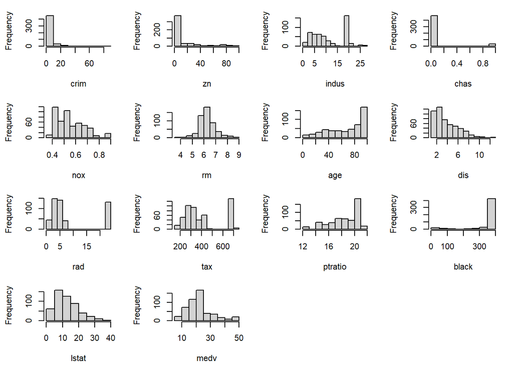

```r
par(mfrow=c(4,4), mai=c(0.6, 0.6, 0.2, 0.2), cex=0.7)
for (i in 1:14) hist(Boston[,i], main="", xlab=names(Boston)[i], cex=0.7)
```

Visualized correlation matrix:

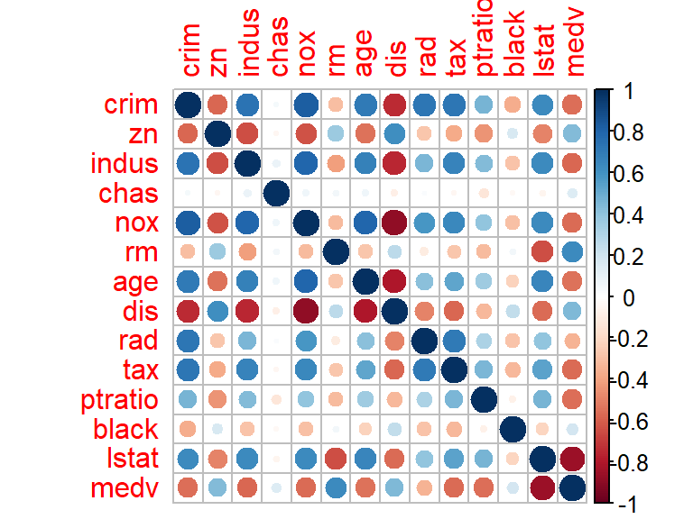

```r
cor_matrix<-cor(Boston, method="spearman")
par(mfrow=c(1,1))
corrplot(cor_matrix, method="circle")
```

```r
# More fancy correlation graph - just for memorize
# corrplot(cor_matrix, method="circle", type="upper", cl.pos = "b", tl.pos = "d" , tl.cex = 0.6)
```

All variables are on very different scale. Most on them are not normally distributed. There are lot of correlations between variables, for example highly negatively are correlated lstat and medv, dis with indus, nox and age. High positive correlation are between nox and indus, age; between indus and tax; between medv and rm.

### 4.2.4 Prepare dataset for discriminant analysis

**Exercise:** Standardize the dataset and print out summaries of the scaled data. How did the variables change? Create a categorical variable of the crime rate in the Boston dataset (from the scaled crime rate). Use the quantiles as the break points in the categorical variable. Drop the old crime rate variable from the dataset. Divide the dataset to train and test sets, so that 80% of the data belongs to the train set.

Center and standardize variables, print out summaries.

```r
boston_scaled <- as.data.frame(scale(Boston))

summary(boston_scaled)
```

```
##       crim                 zn               indus              chas
##  Min.   :-0.419367   Min.   :-0.48724   Min.   :-1.5563   Min.   :-0.2723
##  1st Qu.:-0.410563   1st Qu.:-0.48724   1st Qu.:-0.8668   1st Qu.:-0.2723
##  Median :-0.390280   Median :-0.48724   Median :-0.2109   Median :-0.2723
##  Mean   : 0.000000   Mean   : 0.00000   Mean   : 0.0000   Mean   : 0.0000
##  3rd Qu.: 0.007389   3rd Qu.: 0.04872   3rd Qu.: 1.0150   3rd Qu.:-0.2723
##  Max.   : 9.924110   Max.   : 3.80047   Max.   : 2.4202   Max.   : 3.6648
##       nox                rm               age               dis
##  Min.   :-1.4644   Min.   :-3.8764   Min.   :-2.3331   Min.   :-1.2658
##  1st Qu.:-0.9121   1st Qu.:-0.5681   1st Qu.:-0.8366   1st Qu.:-0.8049
##  Median :-0.1441   Median :-0.1084   Median : 0.3171   Median :-0.2790
##  Mean   : 0.0000   Mean   : 0.0000   Mean   : 0.0000   Mean   : 0.0000
##  3rd Qu.: 0.5981   3rd Qu.: 0.4823   3rd Qu.: 0.9059   3rd Qu.: 0.6617
##  Max.   : 2.7296   Max.   : 3.5515   Max.   : 1.1164   Max.   : 3.9566
##       rad               tax             ptratio            black
##  Min.   :-0.9819   Min.   :-1.3127   Min.   :-2.7047   Min.   :-3.9033
##  1st Qu.:-0.6373   1st Qu.:-0.7668   1st Qu.:-0.4876   1st Qu.: 0.2049
##  Median :-0.5225   Median :-0.4642   Median : 0.2746   Median : 0.3808
##  Mean   : 0.0000   Mean   : 0.0000   Mean   : 0.0000   Mean   : 0.0000
##  3rd Qu.: 1.6596   3rd Qu.: 1.5294   3rd Qu.: 0.8058   3rd Qu.: 0.4332
##  Max.   : 1.6596   Max.   : 1.7964   Max.   : 1.6372   Max.   : 0.4406
##      lstat              medv
##  Min.   :-1.5296   Min.   :-1.9063
##  1st Qu.:-0.7986   1st Qu.:-0.5989
##  Median :-0.1811   Median :-0.1449
##  Mean   : 0.0000   Mean   : 0.0000
##  3rd Qu.: 0.6024   3rd Qu.: 0.2683
##  Max.   : 3.5453   Max.   : 2.9865
```

After centering means of variables are 0.

Use quantiles of variable *crime* as the break points to create a categorical variable. Drop the old crime rate variable from the dataset.

```r
bins <- quantile(boston_scaled$crim)
bins
```

```
##           0%          25%          50%          75%         100%
## -0.419366929 -0.410563278 -0.390280295  0.007389247  9.924109610
```

```r
boston_scaled$crime <- cut(boston_scaled$crim, breaks = bins,
             include.lowest = TRUE,
             label=c("low", "med_low", "med_high", "high"))

table(boston_scaled$crime)
```

```
##
##      low  med_low med_high     high
##      127      126      126      127
```

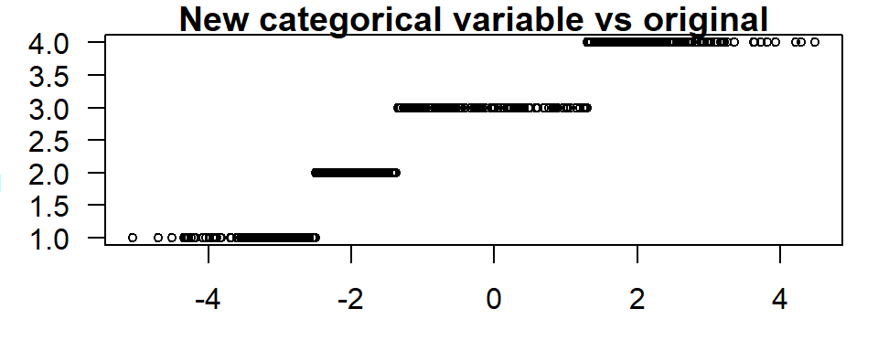

```r
# visualize new vs old crime
par(mai=c(0.6,0.6,0.2,0.2))
plot(log(Boston$crim), boston_scaled$crime, main = "New categorical variable vs original", las=1, cex=0.7)
```

```r
# remove original crim from the dataset
boston_scaled <- dplyr::select(boston_scaled, -crim)
```

Divide dataset to training (80%) and testing (20%) number of rows in the Boston dataset.

```r
# No of rows in dataset
n <- dim(boston_scaled)[1]

# Choose randomly 80% of the rows
ind <- sample(n,  size = n * 0.8)

# Create train set
train <- boston_scaled[ind,]

# Create test set
test <- boston_scaled[-ind,]
```

### 4.2.5 Fit the linear discriminant analysis

**Exercise:** Fit the linear discriminant analysis on the train set. Use the categorical crime rate as the target variable and all the other variables in the dataset as predictor variables. Draw the LDA (bi)plot.

Fit linear discriminant analysis and print the results and make plot.

```r
lda.fit <- lda(crime ~ ., data = train)
lda.fit
```

```
## Call:
## lda(crime ~ ., data = train)
##
## Prior probabilities of groups:
##       low   med_low  med_high      high
## 0.2549505 0.2376238 0.2549505 0.2524752
##
## Group means:
##                  zn      indus        chas        nox         rm        age
## low       1.0987976 -0.9470177 -0.11943197 -0.9131483  0.4992936 -0.9309779
## med_low  -0.1138518 -0.2326483 -0.02626030 -0.5514818 -0.1502849 -0.3075504
## med_high -0.3781741  0.2566057  0.18636222  0.4694781  0.2265408  0.4747248
## high     -0.4872402  1.0171096 -0.07933396  1.0406599 -0.4570127  0.8159213
##                 dis        rad        tax    ptratio       black       lstat
## low       0.9230330 -0.6819317 -0.7336938 -0.4960772  0.38187313 -0.81380237
## med_low   0.3567215 -0.5511961 -0.4378837 -0.0352743  0.30626985 -0.10545536
## med_high -0.4388834 -0.3886824 -0.2629957 -0.3705107  0.05513392 -0.04016905
## high     -0.8572659  1.6382099  1.5141140  0.7808718 -0.88493383  0.89173257
##                 medv
## low       0.59011922
## med_low  -0.02599256
## med_high  0.24746176
## high     -0.67993082
##
## Coefficients of linear discriminants:
##                  LD1           LD2         LD3
## zn       0.071489200  0.7234362035 -0.92583441
## indus    0.028068471 -0.2823730778  0.18686872
## chas    -0.082042580 -0.0239236023  0.14151052
## nox      0.407564956 -0.7860904426 -1.27983420
## rm      -0.083451439 -0.1592377958 -0.17190367
## age      0.306028408 -0.2865989178 -0.16604781
## dis     -0.051385262 -0.2894872423  0.18694490
## rad      2.976260220  0.9816532985 -0.21126845
## tax     -0.001727238 -0.0377911660  0.60797640
## ptratio  0.115679513 -0.0007857647 -0.19673433
## black   -0.138797061 -0.0005781058  0.09627105
## lstat    0.218665535 -0.1740146389  0.53686222
## medv     0.211199920 -0.3741010283 -0.08629199
##
## Proportion of trace:
##    LD1    LD2    LD3
## 0.9326 0.0501 0.0174
```

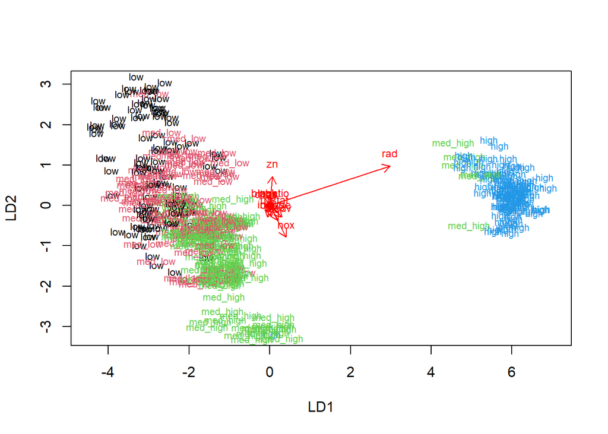

```r
# function for lda biplot arrows
lda.arrows <- function(x, myscale = 1, arrow_heads = 0.1, color = "red", tex = 0.75, choices = c(1,2)){
  heads <- coef(x)
  arrows(x0 = 0, y0 = 0,
         x1 = myscale * heads[,choices[1]],
         y1 = myscale * heads[,choices[2]], col=color, length = arrow_heads)
  text(myscale * heads[,choices], labels = row.names(heads),
       cex = tex, col=color, pos=3)
}
# target classes as numeric
classes <- as.numeric(train$crime)
# plot the lda results
plot(lda.fit , dimen = 2, col=classes, pch=classes)
lda.arrows(lda.fit, myscale = 1)
```

The output presents distribution of target variable, means on descriptive variables in target variable groups and coefficients of linear discriminants (needed to make latent variables describing target variable groups).

### 4.2.6 Testing model on test data

**Exercise:** Save the crime categories from the test set and then remove the categorical crime variable from the test dataset. Then predict the classes with the LDA model on the test data. Cross tabulate the results with the crime categories from the test set. Comment on the results.

```r
# save the correct classes from test data
test$correct_classes <- test$crime

# remove the crime variable from test data
test <- dplyr::select(test, -crime)

# predict classes with test data
lda.pred <- predict(lda.fit, newdata = test)

# cross tabulate the results
a = table(correct = test$correct_classes, predicted = lda.pred$class)
a
```

```
##           predicted
## correct    low med_low med_high high
##   low        9      12        3    0
##   med_low    7      21        2    0
##   med_high   1      17        5    0
##   high       0       0        0   25
```

```r
# correct predictions
sum(a[1,1]+a[2,2]+a[3,3]+a[4,4]) / sum(a)
```

```
## [1] 0.5882353
```

### 4.2.7 Cluster analysis

**Exercise:** Reload the Boston dataset and standardize the dataset (we did not do this in the Datacamp exercises, but you should scale the variables to get comparable distances). Calculate the distances between the observations. Run k-means algorithm on the dataset. Investigate what is the optimal number of clusters and run the algorithm again. Visualize the clusters (for example with the pairs() or ggpairs() functions, where the clusters are separated with colors) and interpret the results.

```r
# Euclidean distance matrix
dist_eu <- dist(boston_scaled)

# Look at the summary of the distances
summary(dist_eu)
```

```
##    Min. 1st Qu.  Median    Mean 3rd Qu.    Max.
##  0.1394  3.5267  4.9081  4.9394  6.2421 13.0045
```

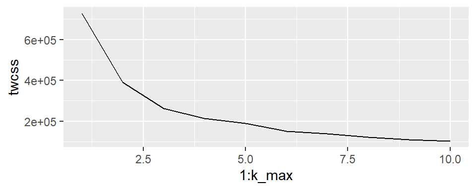

```r
# Determine the number of clusters
set.seed(123)
k_max <- 10

# calculate the total within sum of squares
twcss <- sapply(1:k_max, function(k){kmeans(dist_eu, k)$tot.withinss})

# visualize the results
qplot(x = 1:k_max, y = twcss, geom = 'line')
```

According to the last plot 2 cluster is enough.

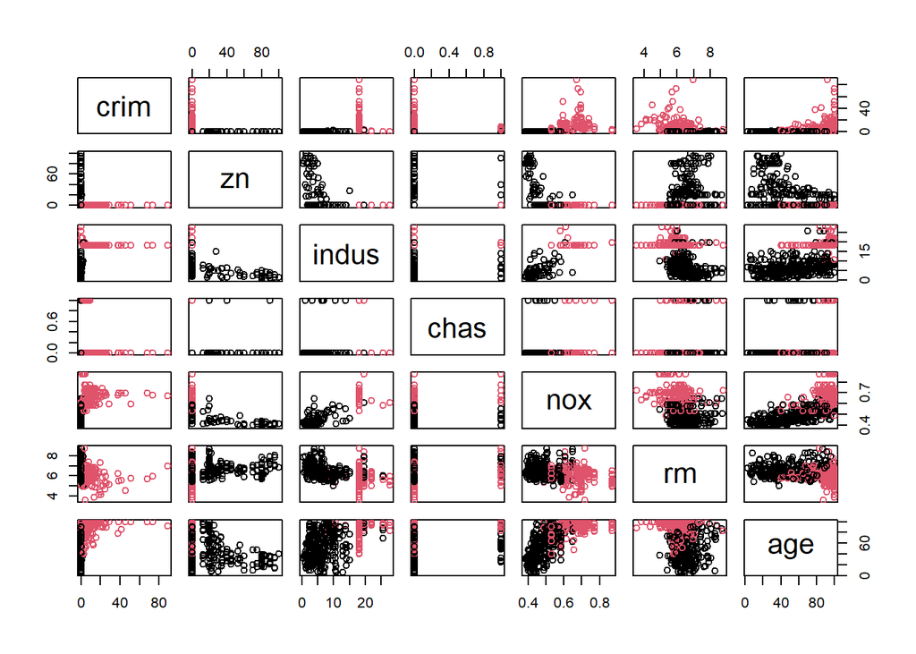

```r
# k-means clustering
km <-kmeans(dist_eu, centers = 2)

# plot the Boston dataset with clusters
pairs(Boston[1:7], col = km$cluster)
```

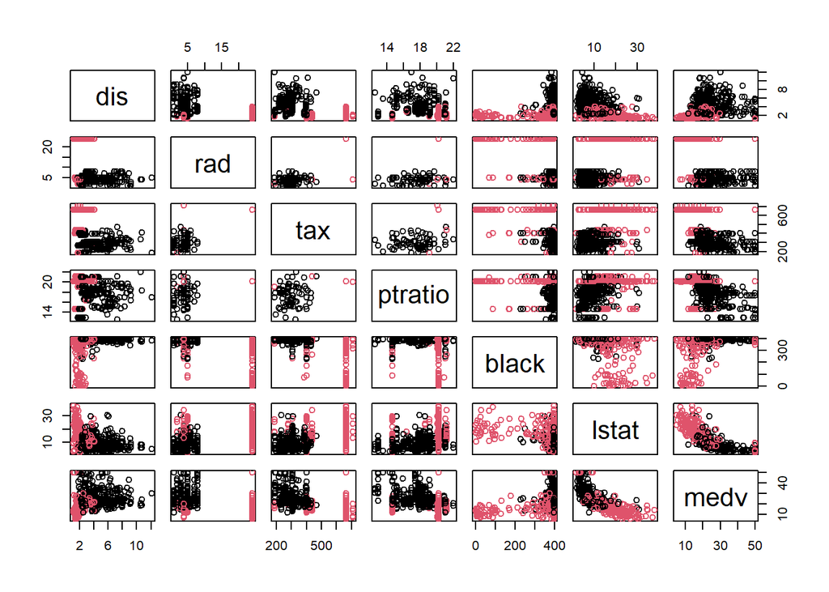

```r
pairs(Boston[8:14], col = km$cluster)
```

I made cluster plots by two graphs. I think that clusters are more clearly separated by variables medv, lstat, age, rm, nox and crime.

### Bonus

**Exercise:** Perform k-means on the original Boston data with some reasonable number of clusters (> 2). Remember to standardize the dataset. Then perform LDA using the clusters as target classes. Include all the variables in the Boston data in the LDA model. Visualize the results with a biplot (include arrows representing the relationships of the original variables to the LDA solution). Interpret the results. Which variables are the most influencial linear separators for the clusters?

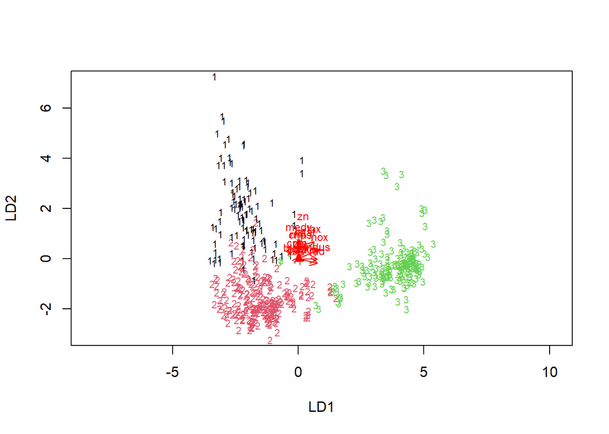

```r
boston_scaled = as.data.frame(scale(Boston))
dist_eu = dist(boston_scaled)
boston_scaled$target<-kmeans(dist_eu, centers = 3)$cluster
lda.fit <- lda(target  ~ ., data = boston_scaled)
classes <- as.numeric(boston_scaled$target)
plot(lda.fit , dimen = 2, col=classes, pch=classes)
lda.arrows(lda.fit, myscale = 1)
```

```r
lda.pred <- predict(lda.fit, newdata = boston_scaled)
a = table(correct = boston_scaled$target, predicted = lda.pred$class)
a
```

```
##        predicted
## correct   1   2   3
##       1  88  17   0
##       2   5 221   4
##       3   0   7 164
```

```r
sum(a[1,1]+a[2,2]+a[3,3]) / sum(a)
```

```
## [1] 0.9347826
```

I did not separate dataset here as trainig and and testing, so the rate of correct answers is high - over 90%.